# Trabajo de Aprendizaje Estadístico | Proyecto Técnicas de Aprendizaje Estadístico aplicadas a empresas editoriales españolas

Máster Universitario en Modelización y Análisis de Datos Económicos (MUMADE)

Autores: Bermann, M.A. & Pérez, R.S. [Grupo D]

12 abril, 2022

# Resumen

Las empresass editoriales están en una transición donde el papel se está viendo sobrepasado por todo lo que pueda sonar a “digital”. En este sentido, en España, las empresas editoriales siempre han ido teniendo cierta importancia gracias a que son una vía de posicionamiento y puesta en valor de la creación artística y literaria de miles de autores, así como por ser canal de producción de productos relacionados con numerosos ámbitos (educativos, ocio, revistas, etc.). En este sentido, es de interés, aplicar técnicas de aprendizaje estadístico para poder dar uso a diferentes métodos de predicción y clasificación, utilizando para ello R. Por tanto, en este proyecto se han aplicado dichas técnicas al caso de empresas editoriales españolas, a partir de la base de datos de Sabi, con el objetivo de realizar y aplicar técnicas predictivas y de análisis y aprendizaje estadístico.

# Importación y tratamiento de datos

Se han utilizado datos de **370 empresas editoriales españolas**, extraídas de la base de datos empresariales Sabi (licencia: [UCLM](https://www.biblioteca.uclm.es/encuentra-informacion/recursos/basesdedatos)), y obteniéndose un *dataset* bidimensional sobre las editoriales españolas. Su dimensión es de 370 x 15, con una columna identificativa con el nombre de empresa y un conjunto de variables económicas, siendo éstas:

- **reneco**: la rentabilidad económica de la empresa. Es el resultado de dividir el resultado del ejercicio entre los activos empresariales.
- **renfin**: la rentabilidad financiera de la empresa. Es el resultado de dividir el resultado del ejercicio entre los fondos propios.
- **liquidez**: la liquidez de la empresa. Es el resultado de dividir los activos líquidos de la empresa entre sus deudas.
- **endeuda**: el nivel de endeudamiento de la empresa. Es el resultado de dividir las deudas entre el total de activos.
- **fpios**: fondos propios. Cantidad absoluta, en miles de euros, de fondos propios de la empresa.
- **res**: resultado del ejercicio. Resultado del ejercicio absoluto, en miles de euros.
- **ing**: ingresos de explotación. Ingresos del ejercicio absolutos, en miles de euros.
- **margen**: margen financiero. Es el resultado de dividir el resultado del ejercicio entre los ingressos de explotación.
- **solvencia**: ratio de solvencia. Es el resultado de dividir el activo a corto plazo entre el pasivo a corto plazo, indicando la capacidad de la empresa de pagar sus deudas a corto plazo.
- **apalanca**: apalancamiento. Es el resultado de dividir la deuda entre los fondos propios.
- **tamaño**: Tamaño de la empresa. Para generar esta variable cualitativa, hemos clasificado las empresas según el número de trabajadores.
- **beneficio**: beneficio de la empresa. Hemos generado esta variable binaria según si la empresa tiene beneficios o pérdidas durante el ejercicio. 1 indica la existencia de beneficios, y 0 de pérdidas.

Cabe decir que se han dividido los datos en un conjunto de **entrenamiento** (train) y otro de **validación** (test), para lo que se ha dijado la semilla para que el resultado sea, oportunamente reproducible.

# Análisis exploratorio de datos

En este primer capítulo de va a proceder a realizar un análisis exploratorio de los datos con los que se va a trabajar para conocer tentativamente sus características.

## Análisis de correlaciones

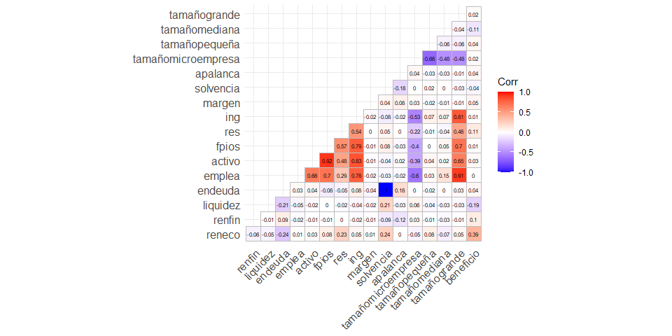

## Análisis de dispersión de datos

En este apartado estamos interesados en ver cómo se distribuyen los datos de algunas de las variables del dataset utilizado. Veamos algunos ejemplos.

- Si observamos la dispersión de la **variable emplea** (número de empleados), podremos ver que hay una serie empresas, de las analizadas, que tienen un gran número de empleados. No obstante, al no ser una medida relativa, procedamos a plantear un gráfico de dispersión de una variable relativa.

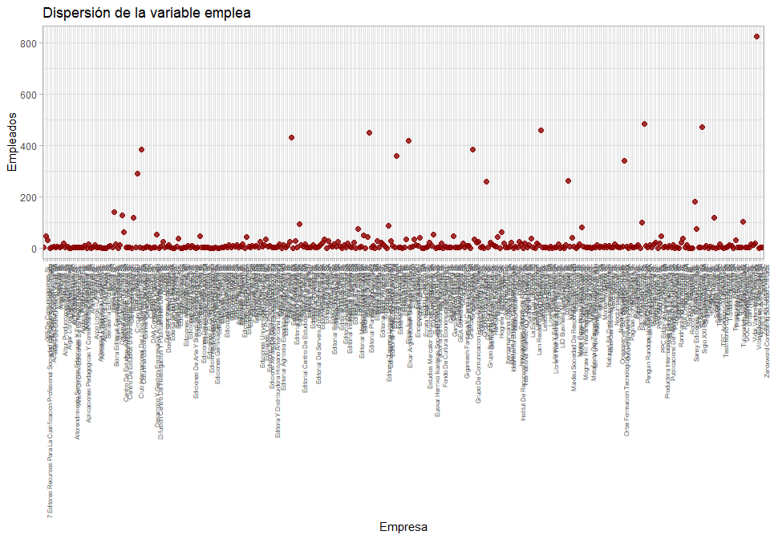

- En cuanto a la distribución de la **variable renfin** (rentabilidad financiera), se observa que la mayor parte de las editoriales, sitúan su rentabilidad financiera en torno a 0, aunque, no obstante, se siguen observando bastantes casos que despuntan. Ya que la media es positiva, es decir, los resultados de la muestra de rentabilidad financiera está sesgada en términos positivos, es una señal de que las empresas editoriales tienen una buena capacidad de generar beneficios a través de sus fondos propios. No obstante, esto podría venir dado por la influencia de grandes empresas que empujan a la muestra a tener un sesgo positivo, pues gráficamente observamos también algunos casos atípicos o influyentes que despuntan por la parte inferior de la media.

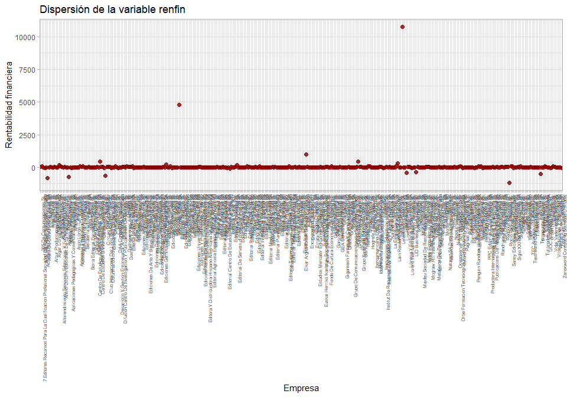

- Podemos plantear también los llamados **gráficos de cajas**. Si lo hacemos para la variable **renfin** observamos como la mayor parte de datos atípicos se sitúan en la zona positiva de valor, pues también encontramos numerosos atípicos pero se sitúan mucho más centrados en torno a la media ya que la baja varianza de la parte central de los datos hace que R entienda como atípicos valores que no están tan lejos según parámetros humanos.

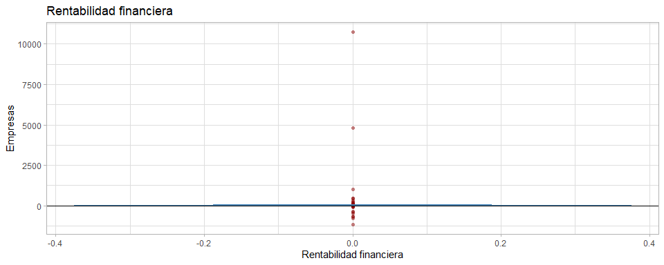

- Si observamos un gráfico de cajas, pero en este caso viendo la relación entre **tamaño** (tamaño) y **renfin** (rentabilidad financiera), observamos que las microempresas, son las que, al tener un nivel de activos inferior, presentan mayor variación en términos de rentabilidad financiera.

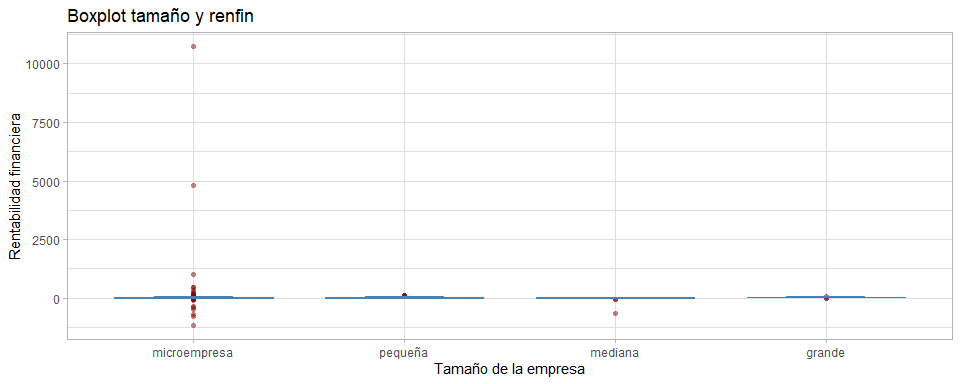

## Análisis de medias por grupos

| beneficio | tamaño | renfin |
| --- | --- | --- |
| 0 | microempresa | -70.07663 |
| 0 | pequeña | -7.54520 |
| 0 | mediana | -111.42571 |
| 0 | grande | -22.25700 |
| 1 | microempresa | 94.23735 |
| 1 | pequeña | 22.47357 |
| 1 | mediana | 9.73025 |
| 1 | grande | 22.16783 |

# Ajuste y predicción de modelos

Tras haber analizado de forma exploratoria algunas de las variables consideradas en el dataset, en este segundo capítulo, se ha escogido la variable **renfin** (rentabilidad financiera), como variable numérica de interés, con el objetivo de predecirla a partir de las demás a través de los distintos tipos de modelos y técnicas de ajuste.

$renfin = f(solvencia, apalanca, endeuda)$

Para desarrollar las técnicas y ajustes de modelos, se escogerán diferentes opciones (en negrita) de entre las que a continuación se detallan, ajustando dichos modelos con los datos de entrenamiento (train) y se evaluarán cada uno de ellos, sus errores, tanto en el conjunto de entrenamiento (train) como de validació (test). En algunos de ellos, es posible que se deba realizar validación cruzada.

- KNN
- **Regresión lineal múltiple**
- **Regresión lineal múltiple con selección de variables**
- Regresión de Ridge
- Lasso
- GAM
- PCR
- PLS
- **Árbol de regresión**
- Árboles usando bagging y boosting
- Random Forests
- SVMs

## Regresión Lineal Múltiple / Multiple Linear Regression

En primer lugar, se propone construir un **modelo de regresión múltiple**, el cual se estimará a través de mínimos cuadrados.

```
Call:
lm(formula = renfin ~ ., data = editoriales, subset = train)

Residuals:
    Min      1Q  Median      3Q     Max
-31.758  -6.835  -1.669   4.743  43.290

Coefficients:
                Estimate Std. Error t value Pr(>|t|)
(Intercept)   -2.311e+07  1.601e+06 -14.436  < 2e-16 ***
reneco         1.936e+00  2.943e-01   6.576 2.01e-08 ***
liquidez       2.777e-01  2.773e-01   1.001 0.321148
endeuda        2.311e+05  1.601e+04  14.436  < 2e-16 ***
emplea         1.859e-01  1.360e-01   1.367 0.177162
activo        -1.367e-03  2.594e-04  -5.270 2.44e-06 ***
fpios          1.474e-05  6.921e-04   0.021 0.983084
res            2.997e-02  6.956e-03   4.308 7.01e-05 ***
ing            4.317e-05  2.579e-04   0.167 0.867711
margen        -8.645e-02  2.163e-02  -3.997 0.000196 ***
solvencia      2.311e+05  1.601e+04  14.436  < 2e-16 ***
apalanca       3.445e-02  3.795e-03   9.079 1.86e-12 ***
tamañopequeña  1.902e+00  6.897e+00   0.276 0.783723
tamañomediana -1.425e+01  1.435e+01  -0.993 0.325193
tamañogrande  -7.180e+01  4.121e+01  -1.742 0.087176 .
beneficio     -3.572e+00  5.329e+00  -0.670 0.505588
---
Signif. codes:  0 '***' 0.001 '**' 0.01 '*' 0.05 '.' 0.1 ' ' 1

Residual standard error: 15.07 on 54 degrees of freedom
Multiple R-squared:  0.8823,    Adjusted R-squared:  0.8496
F-statistic: 26.98 on 15 and 54 DF,  p-value: < 2.2e-16
```

```
                  GVIF Df GVIF^(1/(2*Df))
reneco    6.728263e+00  1    2.593890e+00
liquidez  1.512094e+00  1    1.229672e+00
endeuda   1.324638e+11  1    3.639558e+05
emplea    3.109043e+01  1    5.575879e+00
activo    9.369691e+00  1    3.060995e+00
fpios     1.503420e+01  1    3.877396e+00
res       1.839578e+01  1    4.289030e+00
ing       9.242637e+00  1    3.040171e+00
margen    2.953254e+00  1    1.718503e+00
solvencia 1.324635e+11  1    3.639553e+05
apalanca  1.262887e+00  1    1.123783e+00
tamaño    3.831408e+01  3    1.836086e+00
beneficio 1.323795e+00  1    1.150563e+00
```

- En la **segunda estimación** se acota la estimación considerando la ecuación inicial propuesta ($renfin = f(solvencia, apalanca, endeuda)$), donde la capacidad predictiva baja de forma notable respecto a la primera ecuación, aunque se puede considerar una buena capacidad explicativa del modelo a la hora de determinar las relaciones entre las exógenas y la variable dependiente. Se observa cómo las tres variables se relacionan positivamente con la rentabilidad financiera. Esto significa que la emprea consigue a través de determinados recursos financieros concretos mejorar sus resultados, en este caso el financiero, al relacionarse positivamente con el apalancamiento. Por otra parte, la solvencia también permite mejorar la rentabilidad financiera, es decir, el desahogo financiero (capacidad de hacer frenta a los pagos o pasivos a corto plazo) le permite mejorar su situación de renfin. Y por último, el endeudamiento, que puede venir dado por el uso de esos recursos financieros extraordinarios mencionados, hace a la empresa también tener mejor situación de renfin. En este caso el análisis de inflación de la varianza (vif) sí que muestra síntomas de que pudieran existir problemas de colinealidad por sus elevados valores superiores a 4 para el caso de solvencia y endeuda.

```
Call:
lm(formula = renfin ~ solvencia + apalanca + endeuda, data = editoriales,
    subset = train)

Residuals:
    Min      1Q  Median      3Q     Max
-93.547 -12.167  -7.146   2.410 146.913

Coefficients:
              Estimate Std. Error t value Pr(>|t|)
(Intercept) -1.185e+07  2.675e+06  -4.430 3.63e-05 ***
solvencia    1.185e+05  2.675e+04   4.430 3.63e-05 ***
apalanca     3.069e-02  7.686e-03   3.992 0.000167 ***
endeuda      1.185e+05  2.675e+04   4.430 3.63e-05 ***
---
Signif. codes:  0 '***' 0.001 '**' 0.01 '*' 0.05 '.' 0.1 ' ' 1

Residual standard error: 31.4 on 66 degrees of freedom
Multiple R-squared:  0.3754,    Adjusted R-squared:  0.347
F-statistic: 13.22 on 3 and 66 DF,  p-value: 7.406e-07
```

```
   solvencia     apalanca      endeuda
8.522418e+10 1.193699e+00 8.522414e+10
```

- Por último, se procede a la **validación del modelo de regresión múltiple**. En este punto, calculamos el error medio del modelo generado, utilizando información de la muestra de entrenamiento.

```
[1] 472704.8
```

## Árbol de regresión / Regression tree

En este segundo apartado se va a proceder a ajustar un **árbol de regresión** sobre la base de datos de editoriales que se está utilizando.

- En primer lugar, se creala muestra de entrenamiento y se ajusta el árbol a los datos de entrenamiento. Los resultados nos indican que tenemos que usar 4 variables para construir el árbol. En el contexto del árbol de regresión, la desviación es la suma de los cuadrados de los errores del árbol.

```
Regression tree:
tree(formula = reneco ~ ., data = editoriales, subset = train2)
Variables actually used in tree construction:
[1] "margen"  "emplea"  "renfin"  "endeuda"
Number of terminal nodes:  8
Residual mean deviance:  42.19 = 7468 / 177
Distribution of residuals:
     Min.   1st Qu.    Median      Mean   3rd Qu.      Max.
-55.66000  -1.67800   0.00348   0.00000   1.96500  22.08000
```

- A continuación, se puede **visualizar gráficamente el árbol**. Vemos que la variable que nos ayuda a dividir los datos en grupos más iguales es el margen. El punto de división del margen es 6,73. Si es mayor, el rendimiento será más alto, y si es menor, viceversa. En la parte superior del margen, la siguiente variable que permite sacar conclusiones es la rentabilidad financiera, y en menor medida el endeudamiento. Las empresas con rentabilidad financiera más alta, tendrán un mayor endeudamiento. Las empresas con menor margen, se seguirán dividiendo los grupos por margen, y las que tengan un menor margen, y un número de empleados mayores, serán el subgrupo con los peores datos de rendimiento.

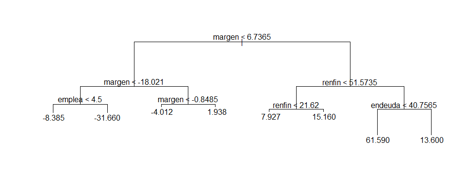

- En este punto, cabe plantearse si reducir las divisiones permite mejorar los resultados obtenidos. Se observa que no es necesario reducir las divisiones para mejorar el árbol al observar el siguiente gráfico.

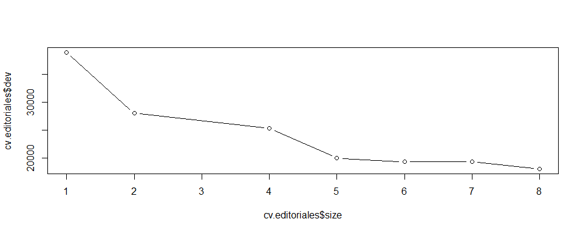

- Ya se pueden realizar las **predicciones de la muestra de validación**. En primer lugar, si se observa el gráfico, el modelo captura de forma bastante aceptable los subgrupos y, si bien un árbol de regresión, al trabajar con medias de subgrupos, puede tener un mayor error, ahora se procederá a comparar con el resto. Respecto al dato del error medio obtenido, el MSE del conjunto de prueba asociado con el árbol de regresión es de 76,31, muestra que el modelo es mejor que el de regresión lineal múltiple.

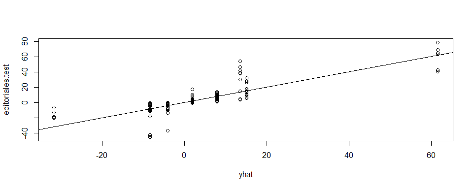

```
[1] 76.30917
```

# Clasificación

En este tercer capítulo, se ha escogido la variable **tamaño** como una variable **categórica**, para predecir a partir del resto de las consideradas.

Para desarrollar las técnicas y ajustes de modelos, se escogerán diferentes opciones (en negrita) de entre las que a continuación se detallan, ajustando dichos modelos con los datos de entrenamiento (train) y se evaluarán cada uno de ellos, sus errores, tanto en el conjunto de entrenamiento (train) como de validació (test). En algunos de ellos, es posible que se deba realizar validación cruzada.

- **KNN**
- Regresión Logística
- Discriminante lineal y cuadrático
- GAM para respuesta categórica
- **Árbol de regresión**
- Árboles usando bagging y boosting
- Random Forests
- **SVMs**

Recordemos que el procedimiento genérico de ajuste de modelos suele seguir la siguiente estructuración:

1. Ajustar modelo en datos *train*
2. Predecir respuesta en datos *test*
3. Evaluar el error en datos *test* y *train*
4. Repetir para distintos modelos
5. Comparar los modelos

## Árbol de clasificación / Classification tree

En esta sección se procederá a realizar un árbol de clasificación y una validación cruzada.

```
              tamaño.test
tree.pred      microempresa pequeña mediana grande
  microempresa          141      11       2      0
  pequeña                 1       4       3      0
  mediana                 0       0       2      1
  grande                  1       0       0      4
```

[output not shown]

- Respecto a la **predicción sobre el total** de los datos considerados (train y test), el acierto aumenta a un 91,62%, un dato incluso superior que sobre la muestra de entrenamiento, fruto a que la muestra de entrenamiento seleccionada sea, seguramente, más difícil de predecir que si se hace, como hemos visto, sobre la muestra total (puede ser por errores más altos).

```
              tamaño
tree.predtotal microempresa pequeña mediana grande
  microempresa          308      16       5      0
  pequeña                 2      10       3      0
  mediana                 1       0       7      1
  grande                  1       2       0     14
```

```
[1] 0.9162162
```

## SVM

A continuación, tras haber realizado el árbol de clasificación, y haber observado su capacidad predictiva, se opta por un **Support Vector Machine (SVM)**.

- Dicha metodología nos muestra cómo el modelo pierde capacidad predictiva respecto al árbol de clasificación en el total del conjunto (en la muestra de test tiene un 89% de acierto frente el 91% obtenido mediante un método de árbol de clasificación en el total del conjunto). Esto supone perder, además, interpretabilidad, con lo que vamos a plantear utilizar otro modelo.

```
              tamaño
svm.predtotal  microempresa pequeña mediana grande
  microempresa          312      26      13      0
  pequeña                 0       2       0      0
  mediana                 0       0       2      1
  grande                  0       0       0     14
```

[output not shown]

## KNN

En este tercer, y último intento, se ha realizado una predicción utilizando el método de *k-vecinos*, obteniendo resultados para ambas muestras (entrenamiento y validación), escogiéndose 4 grupos de k-vecinos al tener 4 tipos de empresas **tamaño** (tamaños de empresas).

```
              tamaño6
knn.predtrain  microempresa pequeña mediana grande
  microempresa          227      12       1      0
  pequeña                 6      10       1      0
  mediana                 1       2       9      0
  grande                  0       1       0     10
```

```
[1] 0.9142857
```

```
              tamaño5
knn.predtest   microempresa pequeña mediana grande
  microempresa           75       2       1      0
  pequeña                 1       0       1      0
  mediana                 1       1       2      0
  grande                  1       0       0      5
```

```
[1] 0.9111111
```

# Conclusiones

Hemos analizado dos variables distintas sobre las empresas editoriales en España, su rentabilidad financiera por un lado y su tamaño, por otro.

# Referencias

En esta sección se incluyen las referencias bibliográficas utilizadas para el desarrollo del proyecto.

[Cano, E. (2022). Introducción al software estadístico R. https://www.lcano.com/b/iser/_book/index.html](https://www.lcano.com/b/iser/_book/index.html)

[James, G. et al. (2021). An introduction to Statistical Learning with Applications in R. Second Edition. Springer](https://www.statlearning.com/)

# Anexos

## Anexo 1. Datos de la sesión

En esta sección se recogen los datos de la sesión utilizada para elaborar este informe. Es fundamental observar la **versión de R**, así como las versiones de los paquetes bajo los cuales se ha ejecutado el código o *script*.

```
R version 4.1.1 (2021-08-10)
Platform: x86_64-w64-mingw32/x64 (64-bit)
Running under: Windows 10 x64 (build 19043)

Matrix products: default

locale:
[1] LC_COLLATE=Spanish_Spain.1252  LC_CTYPE=Spanish_Spain.1252
[3] LC_MONETARY=Spanish_Spain.1252 LC_NUMERIC=C
[5] LC_TIME=Spanish_Spain.1252

attached base packages:
[1] stats     graphics  grDevices utils     datasets  methods   base

other attached packages:
 [1] e1071_1.7-9                class_7.3-19
 [3] ISLR2_1.3-1                car_3.0-12
 [5] carData_3.0-5              tree_1.0-41
 [7] ggcorrplot_0.1.3           corrplot_0.92
 [9] GGally_2.1.2               ez_4.4-0
[11] kableExtra_1.3.4           gt_0.3.1
[13] tibble_3.1.6               knitr_1.37
[15] ggplot2_3.3.5              dplyr_1.0.7
[17] tidyr_1.1.4                PerformanceAnalytics_2.0.4
[19] xts_0.12.1                 zoo_1.8-9
[21] readxl_1.3.1

loaded via a namespace (and not attached):
 [1] httr_1.4.2         sass_0.4.0         jsonlite_1.7.2     viridisLite_0.4.0
 [5] splines_4.1.1      prettydoc_0.4.1    bslib_0.3.1        assertthat_0.2.1
 [9] highr_0.9          cellranger_1.1.0   yaml_2.2.1         pillar_1.6.4
[13] lattice_0.20-45    glue_1.5.0         quadprog_1.5-8     digest_0.6.28
[17] RColorBrewer_1.1-2 rvest_1.0.2        minqa_1.2.4        colorspace_2.0-2
[21] htmltools_0.5.2    Matrix_1.3-4       plyr_1.8.6         pkgconfig_2.0.3
[25] purrr_0.3.4        scales_1.1.1       webshot_0.5.2      svglite_2.0.0
[29] lme4_1.1-27.1      proxy_0.4-26       mgcv_1.8-38        farver_2.1.0
[33] generics_0.1.1     ellipsis_0.3.2     withr_2.4.3        magrittr_2.0.1
[37] crayon_1.4.2       evaluate_0.14      fansi_0.5.0        nlme_3.1-153
[41] MASS_7.3-54        xml2_1.3.3         tools_4.1.1        lifecycle_1.0.1
[45] stringr_1.4.0      munsell_0.5.0      compiler_4.1.1     jquerylib_0.1.4
[49] systemfonts_1.0.3  rlang_0.4.12       grid_4.1.1         nloptr_1.2.2.3
[53] rstudioapi_0.13    labeling_0.4.2     rmarkdown_2.11     boot_1.3-28
[57] gtable_0.3.0       abind_1.4-5        DBI_1.1.2          reshape_0.8.8
[61] reshape2_1.4.4     R6_2.5.1           fastmap_1.1.0      utf8_1.2.2
[65] stringi_1.7.5      Rcpp_1.0.7         vctrs_0.3.8        tidyselect_1.1.1
[69] xfun_0.28
```